# Judge Jude Ole Miss

Project: Building a Natural Language Processing (NLP) framework for the analysis of judicial opinions.

Abstract: The present study used a programmatic, semi-automated approach to collecting criminal case memorandums from Mississippi as well as extracting and organizing the data contained in PDF files. The aim is to develop a Natural Language Processing (NLP) framework for the analysis of text derived from judicial opinions. Here, I present a sample of a Structural Topic Modeling approach that I introduced to this project.

Data: This demo uses data from appellate court documents in the state of Mississippi.

This is part of a larger collaboration with colleagues at the University of Mississippi.

Please note that this notebook contains only a small example from the analyses performed for this project. The purpose of this notebook is to demonstrate the thought process and types of analyses performed and is not exhaustive or complete. The full analyses performed for each project are reported in the published article.

## Load libraries

```python
# Basic libraries
import pandas as pd
import numpy as np
from numpy import triu
import sympy

# Graphs libraries
import matplotlib.pyplot as plt
from matplotlib import cm
import seaborn as sns

# NLP libraries
import nltk
import re
import spacy
import torch

from nltk.corpus import stopwords
from nltk.tokenize import word_tokenize
from nltk.corpus import sentiwordnet as swn
from nltk.corpus import wordnet as wn
from nltk import pos_tag, ne_chunk
nltk.download('punkt')
nltk.download('stopwords')
nltk.download('vader_lexicon')
nltk.download('sentiwordnet')
nltk.download('wordnet')
nltk.download('nrc_lexicon')
nltk.download('averaged_perceptron_tagger')

from gensim import corpora
from gensim.models import LdaModel
from gensim.models.coherencemodel import CoherenceModel

from sklearn.preprocessing import LabelEncoder, OneHotEncoder
from sklearn.feature_extraction.text import CountVectorizer
from sklearn.decomposition import LatentDirichletAllocation
from sklearn.pipeline import Pipeline
from sklearn.decomposition import TruncatedSVD
from sklearn.feature_extraction.text import TfidfVectorizer
from sklearn.cluster import KMeans
from sklearn.decomposition import PCA
from sklearn.manifold import TSNE

from transformers import BertTokenizer, Trainer, TrainingArguments
from textblob import TextBlob
from wordcloud import WordCloud
```

## Load and convert data

```python
### Load excel data and convert to csv

# Define paths
excel_file_path = "/Users/miat./Documents/OtherWork/Jobs-Grants/Portfolio/Jupyter/JudgeJude/Court_Opinions_NLP_Mia.xlsx"
comma_delimited_file_path = "/Users/miat./Documents/OtherWork/Jobs-Grants/Portfolio/Jupyter/JudgeJude/Court_Opinions_NLP_cd.csv"

# Load the Excel file
dfJJnlp = pd.read_excel(excel_file_path)

# Save the dataframe as a comma-delimited CSV file
dfJJnlp.to_csv(comma_delimited_file_path, sep=',', index=False)

# Reload the comma-delimited CSV file
dfJJnlp_comma = pd.read_csv(comma_delimited_file_path, sep=',')

# Print a small sample of data
print(dfJJnlp_comma.iloc[:4, :6])
```

```
   line                 id  section  \
0     0  1998-CA-01189-COA        1
1     1  1998-CA-01189-COA        1
2     2  1998-CA-01189-COA        1
3     3  1998-CA-01189-COA        2

                                           sentences  year  \
0  William E. Davis appeals from an order of summ...  1999
1  After a thorough review of the record, we affi...  1999
2                                              FACTS  1999
3           The uncontroverted facts are as follows:  1999

                                        FULLdoc_text
0  IN THE COURT OF APPEALS OF THE STATE OF MISSIS...
1  IN THE COURT OF APPEALS OF THE STATE OF MISSIS...
2  IN THE COURT OF APPEALS OF THE STATE OF MISSIS...
3  IN THE COURT OF APPEALS OF THE STATE OF MISSIS...
```

## Pre-processing

```python
### Pre-processing

## Drop unnecessary columns
dfJJnlpProc1 = dfJJnlp_comma.drop(columns=['section', 'sentences', 'for_the_court', 'line'])

## Group for repeated rows
dfJJnlpProc1 = dfJJnlpProc1.groupby('id').first().reset_index()

# Print a small sample of data
print(dfJJnlp_comma.iloc[:4, :6])

# Define path to save the processed DataFrame
processed_file_path = "/Users/miat./Documents/OtherWork/Jobs-Grants/Portfolio/Jupyter/JudgeJude/Court_Opinions_NLP_Proc.csv"

# Save the processed DataFrame to a CSV file
dfJJnlpProc1.to_csv(processed_file_path, index=False)

## Create new variable 'NEWyear' from date column (existing 'year' var with all '1999' is appeal year)
# Remove any spaces in the 'date' column
dfJJnlpProc1['date'] = dfJJnlpProc1['date'].str.strip()

# Convert the 'date' column to datetime format
dfJJnlpProc1['date'] = pd.to_datetime(dfJJnlpProc1['date'], format='mixed')

# Create a new column 'NEWyear' that extracts the year from the 'date' column
dfJJnlpProc1['NEWyear'] = dfJJnlpProc1['date'].dt.year

# Verify the new column
print(dfJJnlpProc1['NEWyear'].unique())
```

```
   line                 id  section  \
0     0  1998-CA-01189-COA        1
1     1  1998-CA-01189-COA        1
2     2  1998-CA-01189-COA        1
3     3  1998-CA-01189-COA        2

                                           sentences  year  \
0  William E. Davis appeals from an order of summ...  1999
1  After a thorough review of the record, we affi...  1999
2                                              FACTS  1999
3           The uncontroverted facts are as follows:  1999

                                        FULLdoc_text
0  IN THE COURT OF APPEALS OF THE STATE OF MISSIS...
1  IN THE COURT OF APPEALS OF THE STATE OF MISSIS...
2  IN THE COURT OF APPEALS OF THE STATE OF MISSIS...
3  IN THE COURT OF APPEALS OF THE STATE OF MISSIS...
[1998 1995 1996 1997 1992]
```

## Cleaning

```python
### Cleaning

## Define stop words
stop_words = set(stopwords.words('english'))
custom_stop_words = ['think', 'know', 're', 'would', 'going', 'they', 'things', 'got',
                     'get', 'want', 'way', 'try', 'lot', 'make', 'see', 'go', 'may',
                     'say', 'something', 'people', 'person', 'really', 'someone', 'come',
                     'came', 'small', 'kind', 'could', 'even', 'like', 'much', 'less',
                     'sense', 'time', 'well', 'consider', 'still', 'give', 'na', 'gon', 'sides', 'situation',
                     'seeing', 'let', 'weeks', 'somebody', 'put', 'one', 'two', 'full',
                     'leave', 'cars', 'generally', 'place', 'compared', 'found', 'background', 'us', 'v']
stop_words = stop_words.union(custom_stop_words)
stop_words = list(stop_words)

## Define contraction mapping dictionary
contractions_mapping = {
    "i'm": "i am",
    "i've": "i have",
    "i'll": "i will",
    "we're": "we are",
    "we've": "we have",
    "we'll": "we will",
    "you're": "you are",
    "you've": "you have",
    "you'll": "you will",
    "he's": "he is",
    "he'll": "he will",
    "she's": "she is",
    "she'll": "she will",
    "it's": "it is",
    "it'll": "it will",
    "they're": "they are",
    "they've": "they have",
    "they'll": "they will",
}

# Function to expand contractions
def expand_contractions(text, contractions_mapping):
    pattern = re.compile(r'\b(' + '|'.join(contractions_mapping.keys()) + r')\b')
    def expand_match(contraction):
        return contractions_mapping[contraction.group(0)]
    expanded_text = pattern.sub(expand_match, text)
    return expanded_text

## Function to remove proper nouns
def remove_proper_nouns(tokens):
    tagged = pos_tag(tokens)
    return [word for word, tag in tagged if tag != 'NNP' and tag != 'NNPS']

## Main function to clean and preprocess text
def clean_text(text):
    # Remove non-alphabetic characters
    text = re.sub('[^A-Za-z]', ' ', text)
    # Expand contractions
    text = expand_contractions(text, contractions_mapping)
    # Tokenize the text
    tokens = word_tokenize(text)
    # Remove proper nouns
    tokens = remove_proper_nouns(tokens)
    # Convert to lowercase
    tokens = [word.lower() for word in tokens]
    # Remove stopwords
    cleaned_text = ' '.join([word for word in tokens if word not in stop_words])
    return cleaned_text

## Apply cleaning to var: Cleaned_MAINtext_opinion
dfJJnlpProc1['Cleaned_MAINtext_opinion'] = dfJJnlpProc1['MAINtext_opinion'].apply(clean_text)
dfJJnlpClean = dfJJnlpProc1
cleaned_MAINtext_opinion = dfJJnlpClean['Cleaned_MAINtext_opinion']
```

## WordCloud

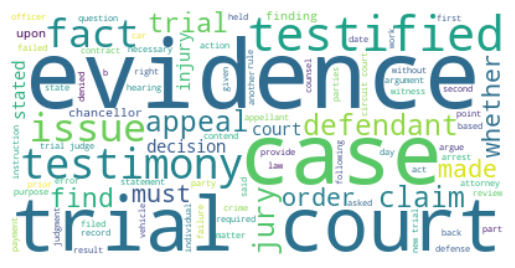

```
<wordcloud.wordcloud.WordCloud at 0x31da85490>
```

```python
### Check data with Word Cloud
from wordcloud import WordCloud
## Var: cleaned_MAINtext_opinion
# Join the different processed titles together.
long_string = ','.join(list(dfJJnlpClean['Cleaned_MAINtext_opinion'].values))
# Create a WordCloud object
wordcloud1 = WordCloud(background_color="white", max_words=5000, contour_width=3, contour_color='steelblue')
# Generate a word cloud
wordcloud1.generate(long_string)

# Visualize the word cloud
wordcloud1.to_image()

# Print and show the plot
plt.imshow(wordcloud1, interpolation='bilinear')
plt.axis("off")
plt.show()

# Opionally save the word cloud to your files
wordcloud1.to_file('wordcloudJJ.pdf')
```

## Topic Modeling

```python
### Topic Model

## Make list of cleaned column texts
documents = dfJJnlpClean['Cleaned_MAINtext_opinion'].tolist()

# Tokenize the documents
tokenized_documents = [doc.split() for doc in documents]

# Create a Gensim dictionary
dictionary = corpora.Dictionary(tokenized_documents)

# Convert the documents to the bag-of-words format
corpus = [dictionary.doc2bow(doc) for doc in tokenized_documents]

# Perform LDA
num_topics = 4
lda_model = LdaModel(corpus=corpus, id2word=dictionary, num_topics=num_topics, passes=15)

# Print the topics
for idx, topic in lda_model.print_topics(-1):
    print(f"Topic: {idx} \nWords: {topic}")

# Evaluate the model coherence score
coherence_model_lda = CoherenceModel(model=lda_model, texts=tokenized_documents, dictionary=dictionary, coherence='c_v')
coherence_lda = coherence_model_lda.get_coherence()
print(f'\nCoherence Score: {coherence_lda}')
```

```
Topic: 0
Words: 0.015*"trial" + 0.014*"evidence" + 0.013*"court" + 0.008*"jury" + 0.007*"testified" + 0.007*"testimony" + 0.006*"case" + 0.006*"instruction" + 0.006*"defense" + 0.005*"whether"
Topic: 1
Words: 0.015*"evidence" + 0.009*"court" + 0.008*"medical" + 0.007*"order" + 0.006*"injury" + 0.006*"chancellor" + 0.006*"support" + 0.006*"law" + 0.005*"judge" + 0.005*"case"
Topic: 2
Words: 0.008*"injury" + 0.008*"contract" + 0.008*"court" + 0.005*"statute" + 0.005*"cause" + 0.005*"chancellor" + 0.005*"property" + 0.005*"trial" + 0.005*"parties" + 0.004*"upon"
Topic: 3
Words: 0.021*"trial" + 0.015*"court" + 0.011*"evidence" + 0.008*"counsel" + 0.007*"jury" + 0.007*"case" + 0.006*"defendant" + 0.005*"conviction" + 0.005*"whether" + 0.005*"error"

Coherence Score: 0.4365833152895141
```

## Structural Topic Modeling

```
Topic 1:
evidence trial court testimony testified attorney defendant counsel issue disability

Topic 2:
chancellor contract court property evidence law parties due damages amount

Topic 3:
court statute trial injury support cause case judgment medical filed

Topic 4:
evidence medical testified court trial instruction back order jury car

Topic 5:
court trial jury party judgment mantle issue case motion shoplifting

Topic 6:
trial evidence court case counsel testimony jury judge defendant whether

                                                     Topic 1   Topic 2  \
nature
CIVIL - CONTRACT                                    0.000229  0.814888
CIVIL - DOMESTIC RELATIONS                          0.333164  0.100804
CIVIL - FELONY                                      0.000307  0.000307
CIVIL - INSURANCE                                   0.000284  0.354294
CIVIL - OTHER                                       0.000743  0.000745
CIVIL - PERSONAL INJURY                             0.000148  0.198801
CIVIL - POST CONVICTION RELIEF                      0.000238  0.000239
CIVIL - POST-CONVICTION RELIEF                      0.000456  0.000455
CIVIL - REAL PROPERTY                               0.000151  0.712183
CIVIL - STATE BOARDS AND AGENCIES                   0.000202  0.000202
CIVIL - TORTS - OTHER THAN PERSONAL INJURY AND ...  0.000312  0.000312
CIVIL - WILLS, TRUSTS AND ESTATES                   0.000390  0.733091
CIVIL - WORKERS' COMPENSATION                       0.100172  0.209523
CRIMINAL - FELONY                                   0.117929  0.001789
CRIMINAL - MISDEMEANOR                              0.025523  0.079430
WORKERS' COMPENSATION                               0.940140  0.000280

                                                     Topic 3   Topic 4  \
nature
CIVIL - CONTRACT                                    0.000229  0.166444
```

[output cut: 19 more lines]

```
CIVIL - DOMESTIC RELATIONS                          0.000257  0.000258
CIVIL - FELONY                                      0.000306  0.000308
CIVIL - INSURANCE                                   0.371043  0.043487
CIVIL - OTHER                                       0.000743  0.996281
CIVIL - PERSONAL INJURY                             0.399813  0.000148
CIVIL - POST CONVICTION RELIEF                      0.000237  0.980703
CIVIL - POST-CONVICTION RELIEF                      0.000455  0.556702
CIVIL - REAL PROPERTY                               0.000150  0.287214
CIVIL - STATE BOARDS AND AGENCIES                   0.000201  0.000202
CIVIL - TORTS - OTHER THAN PERSONAL INJURY AND ...  0.330942  0.168228
CIVIL - WILLS, TRUSTS AND ESTATES                   0.000390  0.265345
CIVIL - WORKERS' COMPENSATION                       0.000312  0.191066
CRIMINAL - FELONY                                   0.060392  0.599737
CRIMINAL - MISDEMEANOR                              0.000477  0.419564
WORKERS' COMPENSATION                               0.000280  0.000280
```

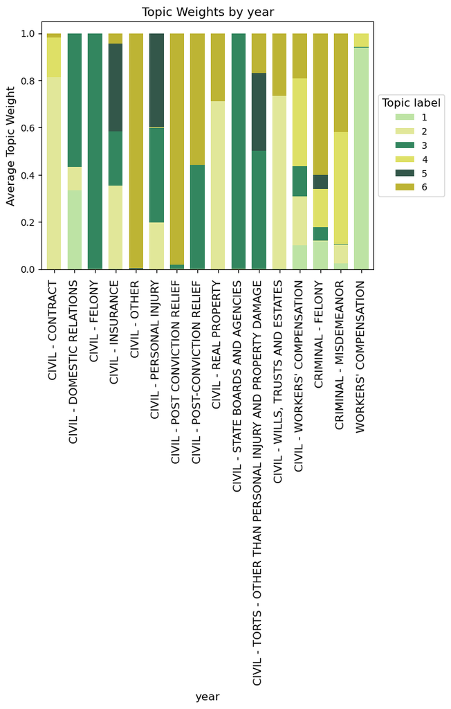

```python
### PLOT 1 - nature

## Create document-term matrix
vectorizer = CountVectorizer(stop_words=stop_words)
dtm = vectorizer.fit_transform(dfJJnlpClean['Cleaned_MAINtext_opinion'])

# Prepare metadata
metadata = dfJJnlpClean[['nature']].values

# One-hot encode metadata
encoder = OneHotEncoder()
metadata_encoded = encoder.fit_transform(metadata)

# Combine document-term matrix and metadata
dtm_with_metadata = np.hstack((dtm.toarray(), metadata_encoded.toarray()))

# Define and train LDA model with metadata (using n topics)
lda_model_with_metadata = LatentDirichletAllocation(n_components=6, random_state=42)
lda_model_with_metadata.fit(dtm_with_metadata)

## Print the top words for each topic
feature_names = vectorizer.get_feature_names_out()
n_top_words = 10
for topic_idx, topic in enumerate(lda_model_with_metadata.components_):
    print(f"Topic {topic_idx + 1}:")
    print(" ".join([feature_names[i] for i in topic.argsort()[:-n_top_words - 1:-1]]))
    print()

# Analyze relationship between topics and metadata
topic_weights = lda_model_with_metadata.transform(dtm_with_metadata)
df_topics = pd.DataFrame(topic_weights, columns=[f'Topic {i+1}' for i in range(6)])
df_topics['nature'] = dfJJnlpClean['nature']
print(df_topics.groupby('nature').mean())

# Calculate average topic weights for each metadata category
avg_topic_weights = df_topics.groupby('nature').mean()

## Plotting
Gcolors = ['#ADDD8E', '#DAE180', '#006837', '#D6D940', '#002D1D', '#ADA101']

Gtopic_labels = ['1', '2', '3', '4', '5', '6',]

plt.figure(figsize=(12, 12))

# Plot the average topic weights
avg_topic_weights.plot(kind='bar', stacked=True, color=Gcolors, alpha=0.8, width=0.7)

# Params
plt.xlabel('year', fontsize=12)
plt.ylabel('Average Topic Weight', fontsize=12)
plt.title('Topic Weights by year', fontsize=13)
plt.xticks(rotation=90, fontsize=12)

plt.legend(labels=Gtopic_labels, title='Topic label', loc='center left', bbox_to_anchor=(1, 0.5), fontsize=10)

plt.setp(plt.gca().get_legend().get_title(), fontsize=12)

plt.show()
```

```
Topic 1:
trial evidence counsel court jury defendant case testimony must attorney

Topic 2:
court evidence attorney law contract chancellor case interest appeal appellant

Topic 3:
medical injury evidence order judge administrative law work disability support

Topic 4:
court trial motion judgment conviction case appeal evidence sentence whether

Topic 5:
trial evidence court jury testified testimony case instruction verdict defense

Topic 6:
evidence due damages arrest court chancellor judgment amount property police

          Topic 1   Topic 2   Topic 3   Topic 4   Topic 5   Topic 6
NEWyear
1992     0.000139  0.000139  0.000139  0.052358  0.947088  0.000139
1995     0.726506  0.000192  0.000192  0.264277  0.008640  0.000192
1996     0.061674  0.074252  0.123605  0.224698  0.515542  0.000229
1997     0.135203  0.149277  0.110697  0.227391  0.253409  0.124024
1998     0.136900  0.180482  0.285713  0.169316  0.142883  0.084706
```

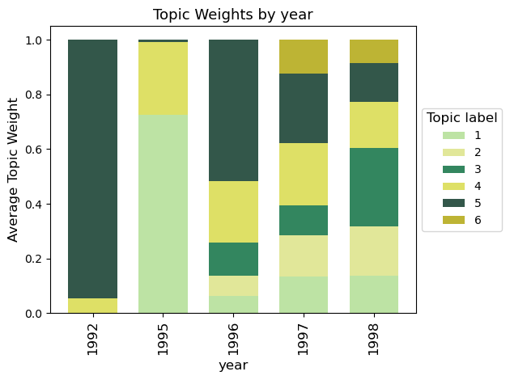

```python
### PLOT 2 - NEWyear

## Create document-term matrix
vectorizer = CountVectorizer(stop_words=stop_words)
dtm = vectorizer.fit_transform(dfJJnlpClean['Cleaned_MAINtext_opinion'])

# Prepare metadata
metadata = dfJJnlpClean[['NEWyear']].values

# One-hot encode metadata
encoder = OneHotEncoder()
metadata_encoded = encoder.fit_transform(metadata)

# Combine document-term matrix and metadata
dtm_with_metadata = np.hstack((dtm.toarray(), metadata_encoded.toarray()))

# Define and train LDA model with metadata (using n topics)
lda_model_with_metadata = LatentDirichletAllocation(n_components=6, random_state=42)
lda_model_with_metadata.fit(dtm_with_metadata)

## Print the top words for each topic
feature_names = vectorizer.get_feature_names_out()
n_top_words = 10
for topic_idx, topic in enumerate(lda_model_with_metadata.components_):
    print(f"Topic {topic_idx + 1}:")
    print(" ".join([feature_names[i] for i in topic.argsort()[:-n_top_words - 1:-1]]))
    print()

# Analyze relationship between topics and metadata
topic_weights = lda_model_with_metadata.transform(dtm_with_metadata)
df_topics = pd.DataFrame(topic_weights, columns=[f'Topic {i+1}' for i in range(6)])
df_topics['NEWyear'] = dfJJnlpClean['NEWyear']
print(df_topics.groupby('NEWyear').mean())

# Calculate average topic weights for each metadata category
avg_topic_weights = df_topics.groupby('NEWyear').mean()

## Plotting
Gcolors = ['#ADDD8E', '#DAE180', '#006837', '#D6D940', '#002D1D', '#ADA101']

Gtopic_labels = ['1', '2', '3',
                '4', '5', '6',]

plt.figure(figsize=(12, 12))

# Plot the average topic weights
avg_topic_weights.plot(kind='bar', stacked=True, color=Gcolors, alpha=0.8, width=0.7)

# Params
plt.xlabel('year', fontsize=12)
plt.ylabel('Average Topic Weight', fontsize=12)
plt.title('Topic Weights by year', fontsize=13)
plt.xticks(rotation=90, fontsize=12)

plt.legend(labels=Gtopic_labels, title='Topic label', loc='center left', bbox_to_anchor=(1, 0.5), fontsize=10)

plt.setp(plt.gca().get_legend().get_title(), fontsize=12)

plt.tight_layout()
#plt.savefig('JJ_NLP_STM_year.png', format='png', dpi = 300, transparent=True)
plt.show()
```

## Conclusions

The STM approach seems promising. While a more detailed cleaning of the corpus could improve results, we can already see that some variables, such as the year of conviction or the type of case, are yielding some interesting results in relation to the topics mentioned in the case memorandums.

Please note that this notebook contains only a small example from the analyses performed for this project. The purpose of this notebook is to demonstrate the thought process and types of analyses performed and is not exhaustive or complete. The full analyses performed for each project are reported in the published article.

Dr. Mia Thomaidou (2024)